# COG Metadata Visualixation - race, age, gender

Jenea Adams

APR 2022

```r
# install.packages("gt", dependencies = T)
# remotes::install_github("ianmoran11/mmtable2")

# install.packages("dplyr", dependencies = T)

# install.packages("tidyverse")

library(dplyr)
library(readr)
library(tidyverse)
```

```r
# library(mmtable2)
library(ggplot2)

# library(dplyr)
```

```r
setwd("~/OneDrive - Children's Hospital of Philadelphia/COG-pediatric-AML/original-metadata-files")

pat.met = read.csv("patient-met.csv", header = T)
wgs = read.csv("WGS.csv", header = T)
rna = read.csv("RNA.csv", header = T)
regno = read.csv("regno-to-caseID.csv", header = T)
```

```r
length(intersect(wgs$case_id, rna$case_id))
```

```
## [1] 390
```

```r
wgs.rna = 390
```

```r
rna_norm = filter(rna, sample_type == "Normal")

rna_tum = filter(rna, sample_type == "Tumor")

# head(rna_tum)

length(Reduce(intersect, list(wgs$case_id, rna_tum$case_id, regno$usi)))
```

```
## [1] 280
```

rna-seq tumor x patient metadata

```r
length(intersect(rna_tum$case_id, regno$usi))
```

```
## [1] 504
```

```r
# rna.tum.pat.met = filter(!wgs$case_id %in% wgs & !rna_norm$case_id %in% rna_norm & rna_tum$case_id & regno$usi)
```

```r
# rna.tum.pat.met = filter(rna, !wgs$case_id %in% c(rna_tum$case_id) & rna_tum$case_id %in% regno$usi )
```

```r
x = filter(rna, rna$case_id %in% wgs$case_id)

nrow(x)
```

```
## [1] 390
```

```r
x1 = filter(rna, rna$case_id %in% wgs$case_id & !wgs$case_id %in% regno$usi)
nrow(x1)
```

```
## [1] 101
```

row 1: wgs x rna_tum x regno

```r
x2 = filter(rna_tum, rna_tum$case_id %in% wgs$case_id & rna_tum$case_id %in% regno$usi & !rna_tum %in% rna_norm)
nrow(x2)
```

```
## [1] 280
```

row 2: !wgs x !rna_norm x rna_tum x pat.met

```r
x3 = filter(rna_tum, !rna_tum$case_id %in%wgs$case_id & !rna_tum$case_id %in% rna_norm$case_id & rna_tum$case_id %in% regno$usi)


nrow(x3)
```

```
## [1] 224
```

row 3: wgs x !rna_norm x rna_tum x !pat.met

```r
x4 = filter(rna_tum, rna_tum$case_id %in%wgs$case_id & !rna_tum$case_id %in% rna_norm$case_id & !rna_tum$case_id %in% regno$usi)

nrow(x4)
```

```
## [1] 110
```

row 4: wgs x !rna_normal x !rna_tum x pat.met

```r
x5 = filter(wgs, !wgs$case_id %in% rna_norm$case_id & !wgs$case_id %in% rna_tum$case_id & wgs$case_id %in% regno$usi)


nrow(x5)
```

```
## [1] 10
```

row 5: wgs x !rna_normal x !rna_tum x !pat.met

```r
x6 = filter(wgs, !wgs$case_id %in% rna_norm$case_id & !wgs$case_id %in% rna_tum$case_id & !wgs$case_id %in% regno$usi)


nrow(x6)
```

```
## [1] 8
```

row 6: !wgs x rna_norm x !rna_tum x !pat.met

```r
# x7 = filter(rna_, !rna_norm$case_id %in%wgs$case_id & !rna_norm$case_id %in% rna_tum$case_id & !rna_tum$case_id %in% regno$usi)
#
# nrow(x7)
```

row 7: !wgs x !rna_norm x rna_tum x !pat.met

```r
x8 = filter(rna_tum, !rna_tum$case_id %in%wgs$case_id & !rna_tum$case_id %in% rna_norm$case_id & !rna_tum$case_id %in% regno$usi)

nrow(x8)
```

```
## [1] 437
```

```r
# pat.met = pat_met
```

```r
x9 = filter(pat.met, pat.met$Patient.registration.number %in% regno$regno)


length(intersect(regno$regno, pat.met$Patient.registration.number))
```

```
## [1] 511
```

```r
nrow(x9)
```

```
## [1] 511
```

# cross-checking usi and sequencing data

## filtering out NAs for case_id

```r
regno.caseID = regno
colnames(regno.caseID)[3] = "case_id"

regno.caseID_noNA = filter(regno.caseID, !case_id == "NA")

nrow(regno.caseID_noNA)
```

```
## [1] 547
```

```r
colnames(pat.met)[1] = "regno"
```

## merging tables based on case_id

```r
regno.caseID_pat.met = merge(regno.caseID_noNA, pat.met, by ="regno")
```

This gives the number of people patient metadata and registration numbers, but sill not merged with cavatica data yet

I will change regno.caseID_pat.met to merged.pat.met

```r
merged.pat.met = regno.caseID_pat.met
```

First, I’d like to see how many people with WGS data also have RNAseq data –> 390 people

```r
x11 = filter(rna, rna$case_id %in% wgs$case_id)
nrow(x11)
```

```
## [1] 390
```

visa versa? –> 390

```r
x12 = filter(wgs, wgs$case_id %in% rna$case_id)
nrow(x12)
```

```
## [1] 390
```

Now I’d like to capture people with WGS AND patient metadata –> 269

```r
wgs.pat.met = filter(wgs, wgs$case_id %in% merged.pat.met$case_id)
nrow(wgs.pat.met)
```

```
## [1] 269
```

I’ll do the same for RNA-seq data –> 470

```r
rna.pat.met = filter(rna, rna$case_id %in% merged.pat.met$case_id)
nrow(rna.pat.met)
```

```
## [1] 470
```

How many patients have RNA-seq, WGS, AND patient metadata?

```r
rna.wgs = filter(rna, rna$case_id %in% wgs$case_id) #390

rna.wgs.pat.met = merge( rna.wgs, merged.pat.met, by = "case_id") #259

nrow(rna.wgs.pat.met)
```

```
## [1] 259
```

How many patients have metadata and EITHER WGS or RNA data?

```r
rna.or.wgs.patmet = filter(merged.pat.met, merged.pat.met$case_id %in% rna$case_id | merged.pat.met$case_id %in% wgs$case_id)
nrow(rna.or.wgs.patmet)
```

```
## [1] 480
```

rna.or.wgs.patmet now becomes cavatica.aaml to demonstrate a merged dataset of cavatica with patient metadata

```r
cavatica.aaml = rna.or.wgs.patmet
```

# defining variables

```r
race = cavatica.aaml$Race.category

age = cavatica.aaml$Age.at.dx..years.

wbc = cavatica.aaml$WBC..x10.3.MicroLiter..levels
```

# Race

Race.category

```r
table(cavatica.aaml$Race.category)
```

```
##
## American Indian or Alaska Native                            Asian
##                                6                               24
##        Black or African American                          Unknown
##                               40                               52
##                            White
##                              358
```

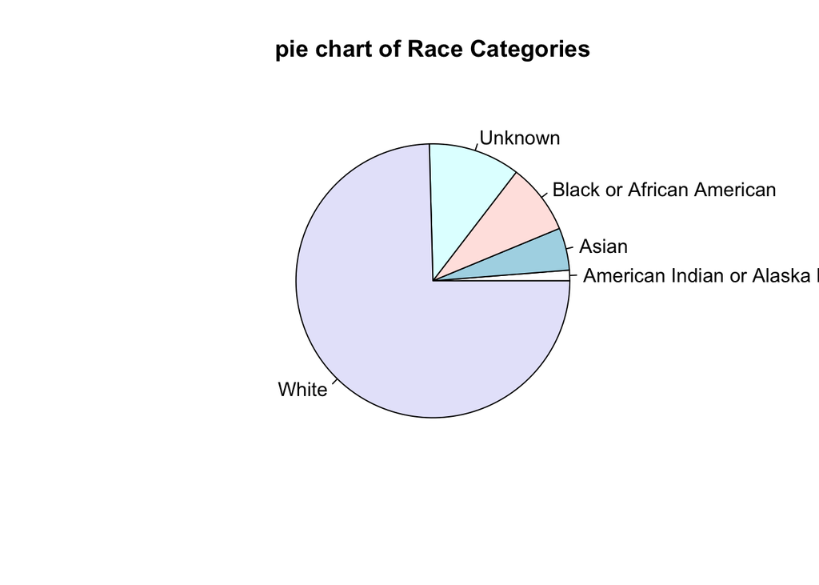

```r
race.table = data.frame(table(cavatica.aaml$Race.category))

pie(race.table$Freq, labels = race.table$Var1, main = "pie chart of Race Categories")
```

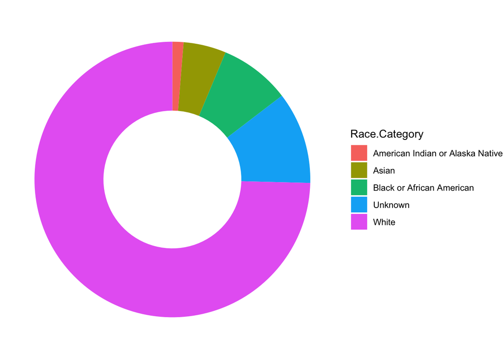

```r
colnames(race.table)[1] = "Race.Category"
colnames(race.table)[2] = "Count"

race.table$fraction = round(race.table$Count/sum(race.table$Count), 3)

race.table$ymax = cumsum(race.table$fraction)

race.table$ymin = c(0, head(race.table$ymax, n=-1))

race_donut_plot = ggplot(race.table, aes(ymax=ymax, ymin=ymin, xmax=4, xmin=3, fill=Race.Category)) +
     geom_rect() +
     coord_polar(theta="y") + # Try to remove that to understand how the chart is built initially
      xlim(c(2, 4)) + theme_void()



race_donut_plot
```

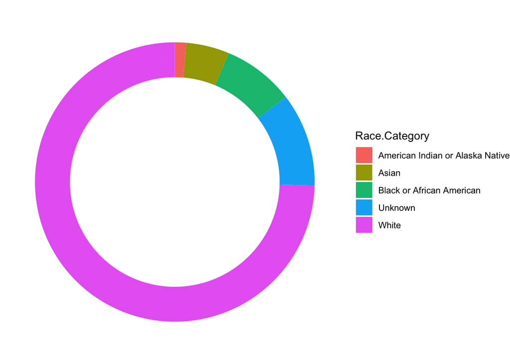

```r
# #compute a label position
# race.table$labelPosition <- (race.table$ymax + race.table$ymin) / 2
#
# Compute a good label
race.table$label <- paste0(race.table$Race.Category, "\n value: ", race.table$Count)


# colnames(race.table)[1] = "Race.Category"

race_donut_plot2 = ggplot(race.table, aes(ymax=ymax, ymin=ymin, xmax=4, xmin=3, fill=Race.Category)) +
  geom_rect() +
  # geom_text( x=2, aes(y=labelPosition, label=label, color=Var1), size=6) +
  coord_polar(theta="y") +
  xlim(c(0, 4)) +
  theme(legend.position = "none")+
  theme_void()



race_donut_plot2
```

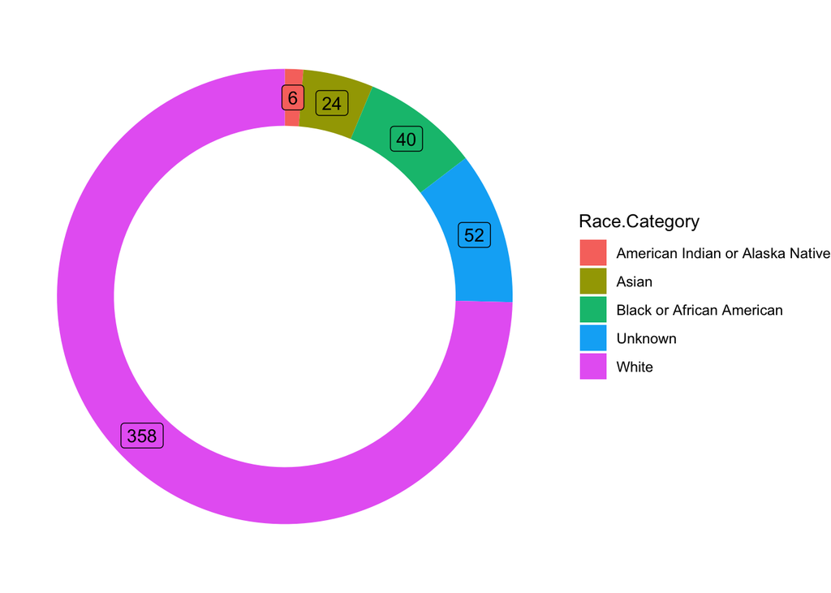

```r
# colnames(race.table)[2] = "Count"


race_donut_plot3 = ggplot(race.table, aes(ymax=ymax, ymin=ymin, xmax=4, xmin=3, fill=Race.Category)) +
  geom_rect() +
  geom_label(aes(label = Count, x = 3.5, y = (ymin+ymax)/2), inherit.aes = T, show.legend = F) +
  coord_polar(theta="y") +
  xlim(c(0, 4)) +
  theme(legend.position = "none")+
  theme_void()

race_donut_plot3
```

# Age

Age at diagnosis in years

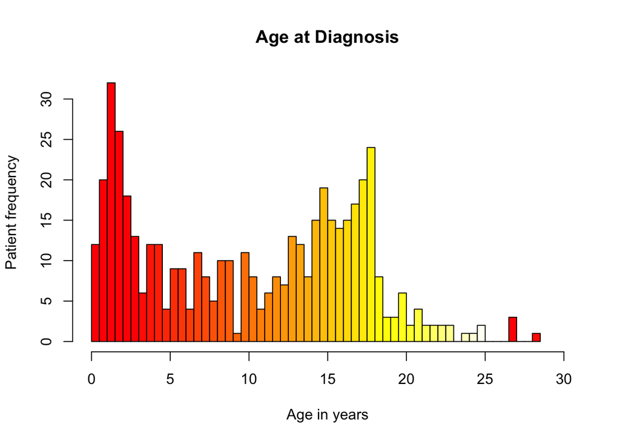

```r
hist(cavatica.aaml$Age.at.dx..years., breaks = 100, main = "Age at Diagnosis", col = heat.colors(50), xlim = c(0,30),
     xlab = "Age in years", ylab = "Patient frequency")
```

# WBC

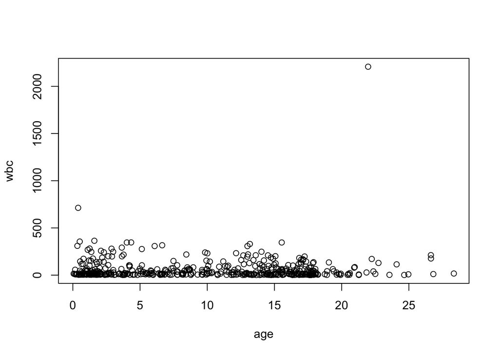

```r
plot(age, wbc)
```

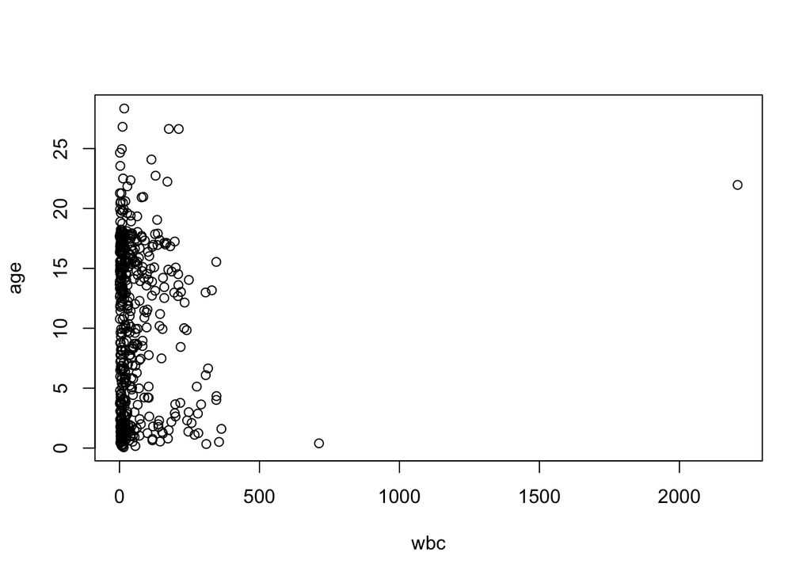

```r
plot(wbc, age)
```

```r
# library(dplyr)
wbc = as.double(wbc)

library(dplyr)


# outlier = filter(wbc, wbc > 1500)
```

```r
# wbc.plot.race = ggplot(wbc, aes(x = WBC))
```

## PCA plot of WBC

```r
wbc.race.age = data.frame(wbc, race, age)
```

```r
library(ggfortify)
```

```r
pca_wbc.race.age = prcomp(wbc.race.age[,c(1,3)], scale =T )
str(pca_wbc.race.age)
```

```
## List of 5
##  $ sdev    : num [1:2] 1.008 0.992
##  $ rotation: num [1:2, 1:2] 0.707 0.707 0.707 -0.707
##   ..- attr(*, "dimnames")=List of 2
##   .. ..$ : chr [1:2] "wbc" "age"
##   .. ..$ : chr [1:2] "PC1" "PC2"
##  $ center  : Named num [1:2] 58.7 10.1
##   ..- attr(*, "names")= chr [1:2] "wbc" "age"
##  $ scale   : Named num [1:2] 126.53 6.78
##   ..- attr(*, "names")= chr [1:2] "wbc" "age"
##  $ x       : num [1:480, 1:2] -0.982 0.554 -0.205 -0.925 0.255 ...
##   ..- attr(*, "dimnames")=List of 2
##   .. ..$ : NULL
##   .. ..$ : chr [1:2] "PC1" "PC2"
##  - attr(*, "class")= chr "prcomp"
```

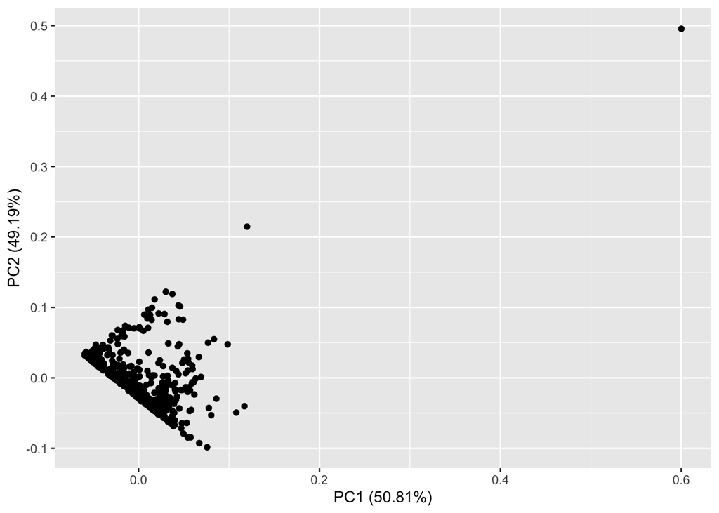

```r
autoplot(pca_wbc.race.age)
```

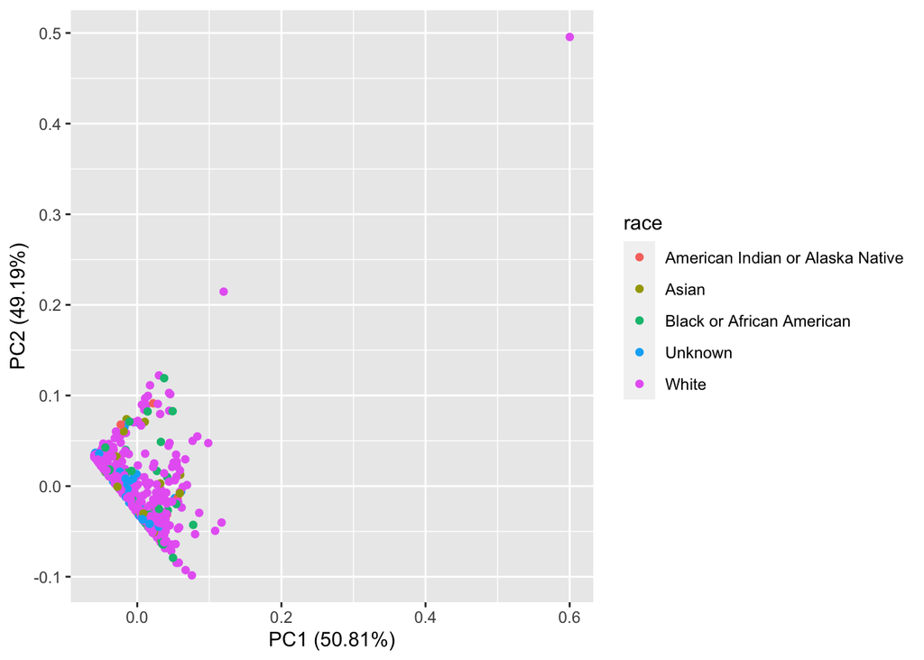

```r
autoplot(pca_wbc.race.age, data = wbc.race.age, colour = "race")
```

removing the outlier

```r
pca_wbc.race.age2 = prcomp(filter(wbc.race.age[,c(1,3)], wbc < 1000), scale =T )
```

```r
summary(wbc)
```

```
##     Min.  1st Qu.   Median     Mean  3rd Qu.     Max.
##    0.800    6.975   18.700   58.672   64.625 2208.000
```

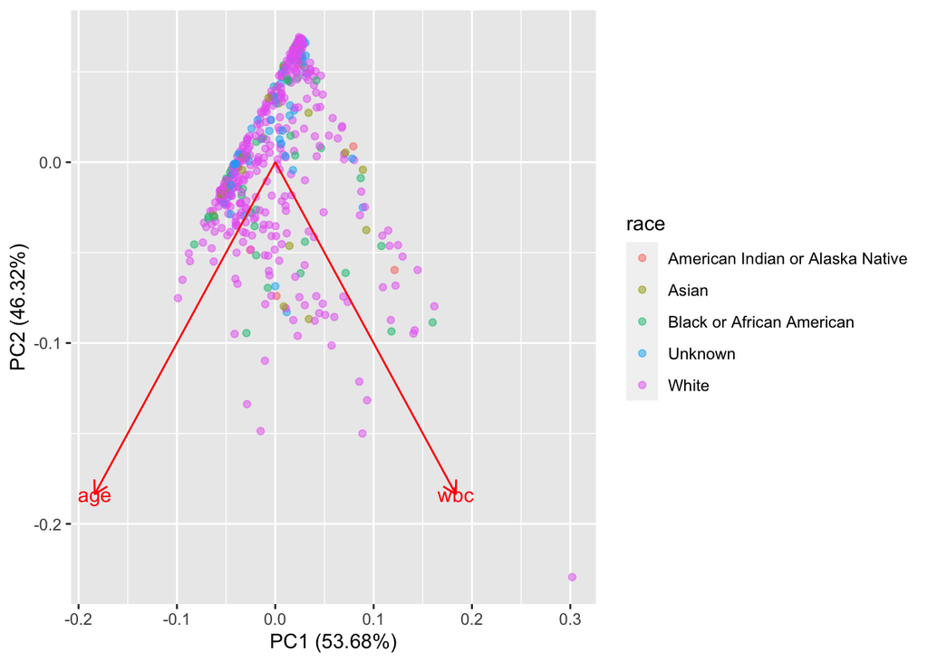

```r
autoplot(pca_wbc.race.age2, data = filter(wbc.race.age, wbc < 1000), colour = "race", alpha = 0.5, loadings.label = TRUE)
```

# Race and Risk Group

```r
risk= cavatica.aaml$Risk.group.classification

race.risk = table(risk, race)

race.risk = race.risk[-1,]
```

Creating a mosaic plot

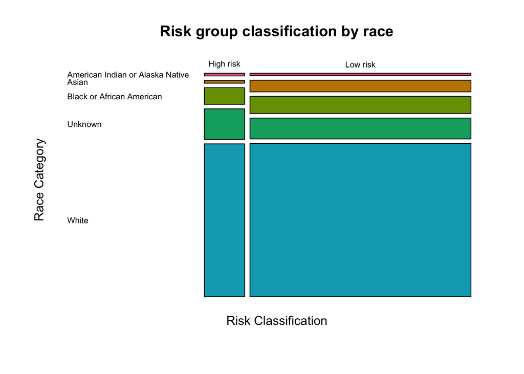

```r
race.risk_mosaic = mosaicplot(race.risk, xlab = "Risk Classification", ylab = "Race Category",
                              main = "Risk group classification by race",
                              col = colorspace::qualitative_hcl(7),
                              clegend = T, las = 1)
```

```r
library(vcd)
```

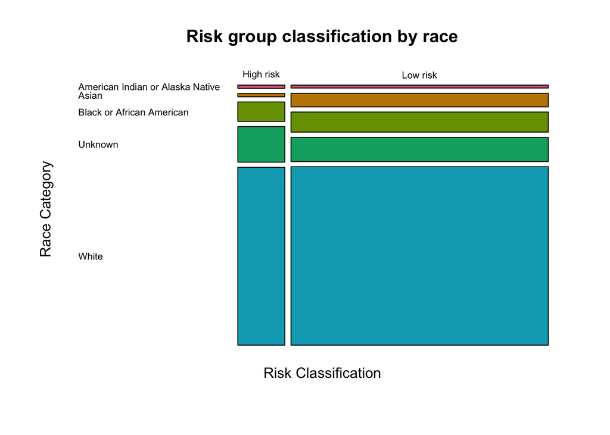

```r
labs <- round(prop.table(race.risk), 2)


race.risk_mosaic = mosaicplot(race.risk, xlab = "Risk Classification", ylab = "Race Category",
                              main = "Risk group classification by race",
                              col = colorspace::qualitative_hcl(7),
                              clegend = T, las = 1)
```

```r
colnames(race.risk)
```

```
## [1] "American Indian or Alaska Native" "Asian"
## [3] "Black or African American"        "Unknown"
## [5] "White"
```

```r
race.risk_noUN = race.risk[,-4]
```

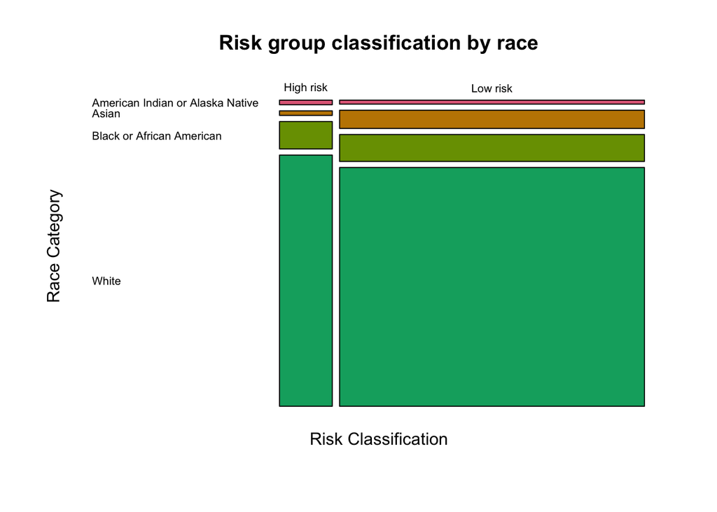

```r
race.risk_noUN_mosaic = mosaicplot(race.risk_noUN, xlab = "Risk Classification", ylab = "Race Category",
                              main = "Risk group classification by race",
                              col = colorspace::qualitative_hcl(7),
                              clegend = T, las = 1)
```

# Death

```r
# cavatica.aaml
```

```r
# filter(cavatica.aaml, !cavatica.aaml$Date.of.death == ".")
```

```r
# library(ggplot2)
# library(scales)
# library(lubridate)
```

```r
# library(vistime)
#
# gg_vistime()
```

# Race Categories and outcomes

I will do a linear regression to determine if there’s a relationship between the race categories and risk and disease outcomes

```r
colnames(cavatica.aaml)
```

```
##  [1] "regno"
##  [2] "barcode"
##  [3] "case_id"
##  [4] "batch"
##  [5] "FID"
##  [6] "study"
##  [7] "eligable"
##  [8] "consent"
##  [9] "Date.of.diagnosis"
## [10] "Date.of.enrollment"
## [11] "Date.of.birth"
## [12] "GENDER"
## [13] "Treatment.Arm"
## [14] "Age.at.dx..years."
## [15] "WBC..x10.3.MicroLiter..levels"
## [16] "Race.category"
## [17] "Ethnicity.category"
## [18] "Method.of.payment"
## [19] "Was.indicated.evaluation.performed.during.this.reporting.period....Echocardiogram..ECHO..at.baseline"
## [20] "If.ECHO.was.performed..Was.the.indicated.test.performed....Of.Shortening.Fraction.from.ECHO.at.baseline"
## [21] "What.was.the.percentage....Of.Shortening.Fraction.from.ECHO.at.baseline"
## [22] "If.ECHO.was.performed..Was.the.indicated.test.performed....Of.Ejection.Fraction.from.ECHO.at.baseline"
## [23] "What.was.the.percentage....Of.Ejection.Fraction.from.ECHO.at.baseline"
## [24] "Risk.group.classification"
## [25] "Date.of.first.relapse"
## [26] "New.cancer.diagnosis.date"
## [27] "Date.of.death"
## [28] "Date.of.last.contact"
```

Creating indicator variables for the race categories

```r
library(fastDummies)


cavatica.aaml.ind = dummy_cols(cavatica.aaml, select_columns = "Race.category")

cavatica.aaml.ind = dummy_cols(cavatica.aaml.ind, select_columns = "Risk.group.classification")

colnames(cavatica.aaml.ind)
```

```
##  [1] "regno"
##  [2] "barcode"
##  [3] "case_id"
##  [4] "batch"
##  [5] "FID"
##  [6] "study"
##  [7] "eligable"
##  [8] "consent"
##  [9] "Date.of.diagnosis"
## [10] "Date.of.enrollment"
## [11] "Date.of.birth"
## [12] "GENDER"
## [13] "Treatment.Arm"
## [14] "Age.at.dx..years."
## [15] "WBC..x10.3.MicroLiter..levels"
```

[output cut: 21 more lines]

```r
high.risk.ind = cavatica.aaml.ind$`Risk.group.classification_High risk`

aian.ind = cavatica.aaml.ind$`Race.category_American Indian or Alaska Native`
asian.ind = cavatica.aaml.ind$Race.category_Asian
black.ind = cavatica.aaml.ind$`Race.category_Black or African American`
race_unkown.ind = cavatica.aaml.ind$Race.category_Unknown
white.ind = cavatica.aaml.ind$Race.category_White


race.risk.fit = lm(high.risk.ind ~ aian.ind + asian.ind + black.ind + race_unkown.ind + white.ind, data = cavatica.aaml)
```

```r
race.risk.fit0 = lm(high.risk.ind ~ black.ind + white.ind + asian.ind + aian.ind, data = cavatica.aaml.ind)

summary(race.risk.fit0)
```

```
##
## Call:
## lm(formula = high.risk.ind ~ black.ind + white.ind + asian.ind +
##     aian.ind, data = cavatica.aaml.ind)
##
## Residuals:
##     Min      1Q  Median      3Q     Max
## -0.2115 -0.1536 -0.1536 -0.1500  0.9583
##
## Coefficients:
##             Estimate Std. Error t value Pr(>|t|)
## (Intercept)  0.21154    0.05015   4.218 2.95e-05 ***
## black.ind   -0.06154    0.07605  -0.809   0.4188
## white.ind   -0.05791    0.05367  -1.079   0.2811
## asian.ind   -0.16987    0.08924  -1.904   0.0576 .
## aian.ind    -0.04487    0.15592  -0.288   0.7736
## ---
## Signif. codes:  0 '***' 0.001 '**' 0.01 '*' 0.05 '.' 0.1 ' ' 1
##
## Residual standard error: 0.3616 on 475 degrees of freedom
## Multiple R-squared:  0.007615,   Adjusted R-squared:  -0.0007418
## F-statistic: 0.9112 on 4 and 475 DF,  p-value: 0.4571
```

```r
anova(race.risk.fit0)
```

```
## Analysis of Variance Table
##
## Response: high.risk.ind
##            Df Sum Sq Mean Sq F value  Pr(>F)
## black.ind   1  0.001 0.00076  0.0058 0.93936
## white.ind   1  0.002 0.00161  0.0123 0.91182
## asian.ind   1  0.463 0.46345  3.5440 0.06037 .
## aian.ind    1  0.011 0.01083  0.0828 0.77363
## Residuals 475 62.115 0.13077
## ---
## Signif. codes:  0 '***' 0.001 '**' 0.01 '*' 0.05 '.' 0.1 ' ' 1
```

```r
summary(race.risk.fit0)
```

```
##
## Call:
## lm(formula = high.risk.ind ~ black.ind + white.ind + asian.ind +
##     aian.ind, data = cavatica.aaml.ind)
##
## Residuals:
##     Min      1Q  Median      3Q     Max
## -0.2115 -0.1536 -0.1536 -0.1500  0.9583
##
## Coefficients:
##             Estimate Std. Error t value Pr(>|t|)
## (Intercept)  0.21154    0.05015   4.218 2.95e-05 ***
## black.ind   -0.06154    0.07605  -0.809   0.4188
## white.ind   -0.05791    0.05367  -1.079   0.2811
## asian.ind   -0.16987    0.08924  -1.904   0.0576 .
## aian.ind    -0.04487    0.15592  -0.288   0.7736
## ---
## Signif. codes:  0 '***' 0.001 '**' 0.01 '*' 0.05 '.' 0.1 ' ' 1
##
## Residual standard error: 0.3616 on 475 degrees of freedom
## Multiple R-squared:  0.007615,   Adjusted R-squared:  -0.0007418
## F-statistic: 0.9112 on 4 and 475 DF,  p-value: 0.4571
```

```r
anova(race.risk.fit0)
```

```
## Analysis of Variance Table
##
## Response: high.risk.ind
##            Df Sum Sq Mean Sq F value  Pr(>F)
## black.ind   1  0.001 0.00076  0.0058 0.93936
## white.ind   1  0.002 0.00161  0.0123 0.91182
## asian.ind   1  0.463 0.46345  3.5440 0.06037 .
## aian.ind    1  0.011 0.01083  0.0828 0.77363
## Residuals 475 62.115 0.13077
## ---
## Signif. codes:  0 '***' 0.001 '**' 0.01 '*' 0.05 '.' 0.1 ' ' 1
```

Now I’d like to use the dates of first relapse feature

```r
cavatica.aaml.relapse = filter(cavatica.aaml, !Date.of.first.relapse == ".")

# length(cavatica.aaml.relapse$Date.of.first.relapse)
#
# race.relapse.table = table(cavatica.aaml.relapse %>% select(Date.of.first.relapse, Race.category))
#
# x = as.data.frame(race.relapse.table)
#
# colnames(x)
```

```r
# colnames(race.relapse.table)
```

Visualizing race category distribution fo the relapse dates

```r
# race.relapse.donut_plot1 = ggplot(race.relapse.table, aes(ymax=ymax, ymin=ymin, xmax=4, xmin=3, fill=Race.Category)) +
#   geom_rect() +
#   geom_label(aes(label = Count, x = 3.5, y = (ymin+ymax)/2), inherit.aes = T, show.legend = F) +
#   coord_polar(theta="y") +
#   xlim(c(0, 4)) +
#   theme(legend.position = "none")+
#   theme_void()
#
# race_donut_plot1
```

```r
class(cavatica.aaml.relapse$Date.of.first.relapse)
```

```
## [1] "character"
```

```r
# cavatica.aaml.relapse$WBC..x10.3.MicroLiter..levels

library(linelist)

cavatica.aaml.relapse$Date.of.first.relapse = guess_dates(cavatica.aaml.relapse$Date.of.first.relapse)

class(cavatica.aaml.relapse$Date.of.first.relapse) # now all dates are of the date class
```

```
## [1] "Date"
```

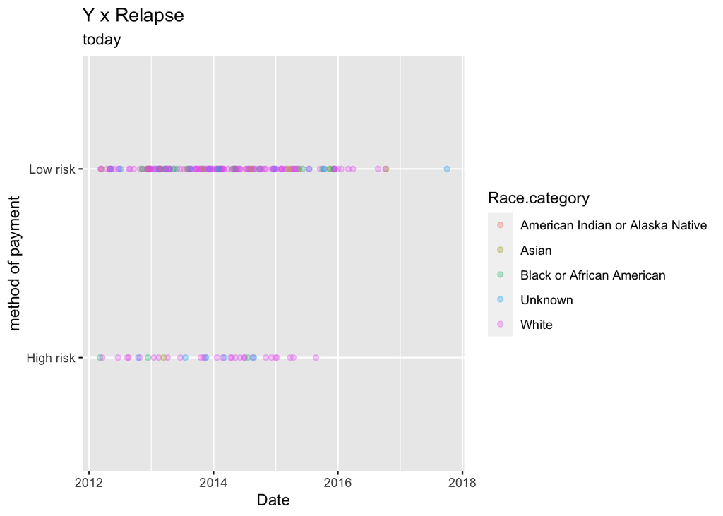

```r
ggplot(data = cavatica.aaml.relapse, aes(x = Date.of.first.relapse, y = Risk.group.classification , color = Race.category)) +
  geom_point(alpha = 0.3) +
  labs(x = "Date",
    y = "method of payment",
    title = "Y x Relapse",
    subtitle = "today")
```

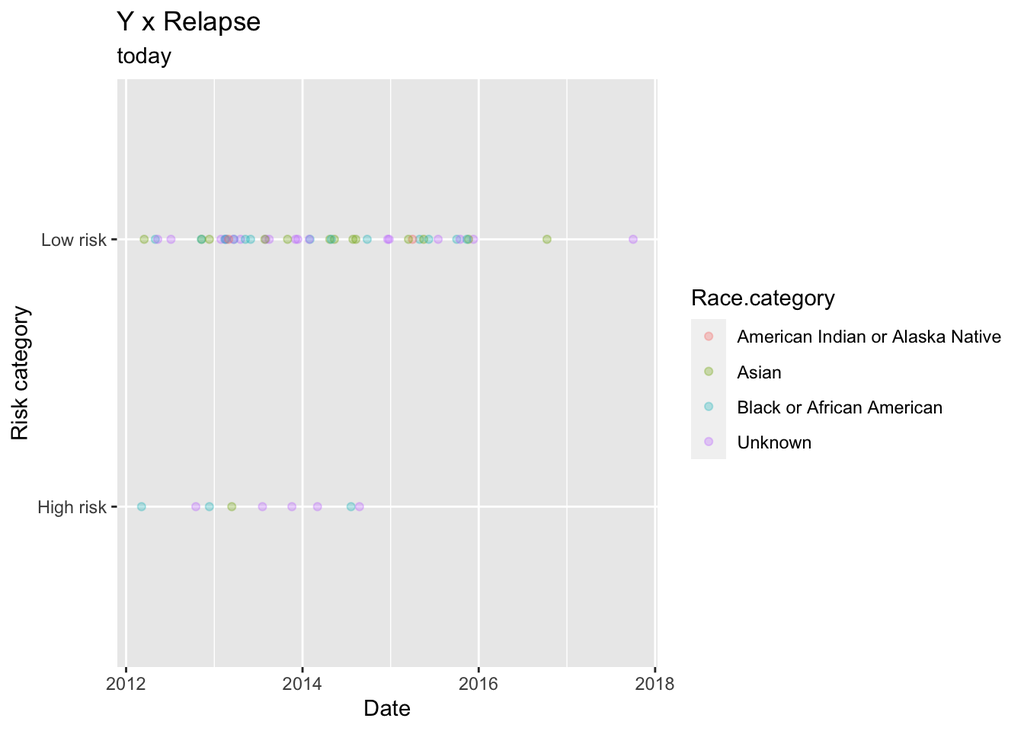

```r
ggplot(data = filter(cavatica.aaml.relapse, !Race.category == "White"), aes(x = Date.of.first.relapse, y = Risk.group.classification , color = Race.category)) +
  geom_point(alpha = 0.3) +
  labs(x = "Date",
    y = "Risk category",
    title = "Y x Relapse",
    subtitle = "today")
```

```r
nrow(filter(cavatica.aaml.relapse, Date.of.first.relapse < as.Date("2014-01-01") & Race.category =="Black or African American"))
```

```
## [1] 9
```

```r
nrow(filter(cavatica.aaml.relapse, Date.of.first.relapse < as.Date("2014-01-01") & Race.category =="Asian"))
```

```
## [1] 6
```

```r
nrow(filter(cavatica.aaml.relapse, Date.of.first.relapse < as.Date("2014-01-01") & Race.category =="Black or African American" & Risk.group.classification == "High risk") )
```

```
## [1] 2
```

```r
library(ggplot2)
library(scales)
library(lubridate)
library(vistime)
```

```r
colnames(cavatica.aaml.relapse)
```

```
##  [1] "regno"
##  [2] "barcode"
##  [3] "case_id"
##  [4] "batch"
##  [5] "FID"
##  [6] "study"
##  [7] "eligable"
##  [8] "consent"
##  [9] "Date.of.diagnosis"
## [10] "Date.of.enrollment"
## [11] "Date.of.birth"
## [12] "GENDER"
## [13] "Treatment.Arm"
## [14] "Age.at.dx..years."
## [15] "WBC..x10.3.MicroLiter..levels"
## [16] "Race.category"
## [17] "Ethnicity.category"
## [18] "Method.of.payment"
## [19] "Was.indicated.evaluation.performed.during.this.reporting.period....Echocardiogram..ECHO..at.baseline"
## [20] "If.ECHO.was.performed..Was.the.indicated.test.performed....Of.Shortening.Fraction.from.ECHO.at.baseline"
## [21] "What.was.the.percentage....Of.Shortening.Fraction.from.ECHO.at.baseline"
## [22] "If.ECHO.was.performed..Was.the.indicated.test.performed....Of.Ejection.Fraction.from.ECHO.at.baseline"
## [23] "What.was.the.percentage....Of.Ejection.Fraction.from.ECHO.at.baseline"
## [24] "Risk.group.classification"
## [25] "Date.of.first.relapse"
## [26] "New.cancer.diagnosis.date"
## [27] "Date.of.death"
## [28] "Date.of.last.contact"
```

```r
cavatica.aaml.relapse$Date.of.enrollment = guess_dates(cavatica.aaml.relapse$Date.of.enrollment)

cavatica.aaml.relapse$Date.of.enrollment
```

```
##   [1] "2011-06-07" "2011-09-08" "2011-12-08" "2011-08-19" "2011-08-23"
##   [6] "2011-09-10" "2011-12-10" "2011-10-28" "2011-10-29" "2011-03-11"
##  [11] "2011-11-16" "2011-11-16" "2011-11-17" "2011-11-21" "2011-06-12"
##  [16] "2011-08-12" "2011-12-15" "2011-12-22" "2011-12-22" "2011-12-29"
##  [21] "2011-12-31" "2012-03-01" "2012-09-01" "2012-07-01" "2012-12-01"
##  [26] "2012-01-13" "2012-01-02" "2012-02-24" "2012-02-27" "2012-02-28"
##  [31] "2012-02-28" "2012-02-03" "2012-02-03" "2012-08-03" "2012-09-03"
##  [36] "2012-09-03" "2012-03-14" "2012-03-19" "2012-03-14" "2012-03-22"
##  [41] "2012-03-23" "2012-03-30" "2012-03-30" "2012-06-04" "2012-10-04"
##  [46] "2012-04-24" "2012-01-05" "2012-04-05" "2012-03-05" "2012-03-05"
##  [51] "2012-08-05" "2012-05-15" "2012-05-16" "2012-05-18" "2012-06-18"
##  [56] "2012-05-24" "2012-06-06" "2012-05-06" "2012-07-06" "2012-12-06"
##  [61] "2012-06-14" "2012-06-14" "2012-06-20" "2012-06-21" "2012-03-07"
##  [66] "2012-06-28" "2012-06-28" "2012-06-30" "2012-07-07" "2012-11-07"
##  [71] "2012-07-20" "2012-07-25" "2012-07-26" "2012-07-31" "2012-06-08"
```

[output cut: 28 more lines]

```r
# vistime(cavatica.aaml.relapse, col.start = as.character(cavatica.aaml.relapse$Date.of.enrollment), col.end = as.character(Date.of.first.relapse), col.group = Race.category, col.color = race_colors)
```

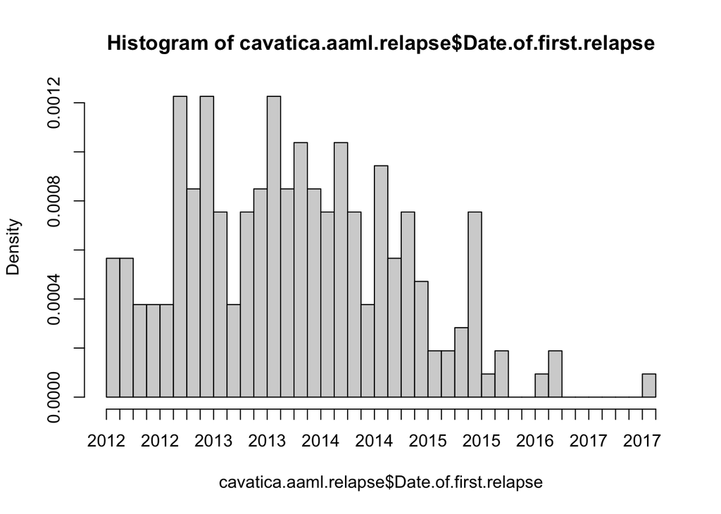

```r
hist(cavatica.aaml.relapse$Date.of.first.relapse, breaks = 50)
```

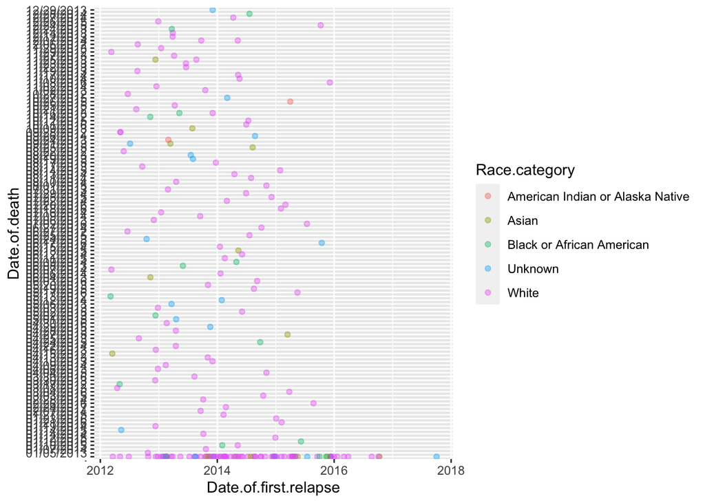

```r
# cavatica.aaml.relapse$Date.of.death = guess_dates(cavatica.aaml.relapse$Date.of.death)

# cavatica.aaml.relapse = cavatica.aaml.relapse %>% filter(!Date.of.death == ".")



ggplot(cavatica.aaml.relapse, aes(x = Date.of.first.relapse , y = Date.of.death, color = Race.category)) + geom_point(alpha = 0.4)
```

```r
cavatica.aaml.relapse$diffEnrollRelapse = difftime(cavatica.aaml.relapse$Date.of.first.relapse, cavatica.aaml.relapse$Date.of.enrollment, units = "weeks")
# cavatica.aaml$diffEnrollRelapse = difftime(cavatica.aaml$Date.of.first.relapse, cavatica.aaml$Date.of.enrollment, units = "weeks")
```

Mean time to relapse for different race groups after enrollment

```r
class(cavatica.aaml.relapse$diffEnrollRelapse) = "numeric"
# lapply(race.df.list, function(x){mean(x$diffEnrollRelapse)})

black.relapse = filter(cavatica.aaml.relapse, Race.category == "Black or African American")
class(black.relapse$diffEnrollRelapse) = "numeric"


white.relapse = filter(cavatica.aaml.relapse, Race.category == "White")
class(white.relapse$diffEnrollRelapse) = "numeric"


asian.relapse = filter(cavatica.aaml.relapse, Race.category == "Asian")
class(asian.relapse$diffEnrollRelapse) = "numeric"


aian.relapse = filter(cavatica.aaml.relapse, Race.category == "American Indian or Alaska Native")
class(aian.relapse$diffEnrollRelapse) = "numeric"


race.df.list.relapse = list(black.relapse, white.relapse, asian.relapse, aian.relapse)


lapply(race.df.list.relapse, function(x){mean(x$diffEnrollRelapse)})
```

```
## [[1]]
## [1] 44.21008
##
## [[2]]
## [1] 52.07279
##
## [[3]]
## [1] 60.86735
##
## [[4]]
## [1] 40.78571
```

Running a t-test on the difference in time to first relapse by race category

```r
t.test(black.relapse$diffEnrollRelapse, white.relapse$diffEnrollRelapse, paired = F)
```

```
##
##  Welch Two Sample t-test
##
## data:  black.relapse$diffEnrollRelapse and white.relapse$diffEnrollRelapse
## t = -1.2792, df = 22.726, p-value = 0.2137
## alternative hypothesis: true difference in means is not equal to 0
## 95 percent confidence interval:
##  -20.585883   4.860464
## sample estimates:
## mean of x mean of y
##  44.21008  52.07279
```

Trying a Mann-Whitney U test

```r
# wilcox.test(black.relapse$diffEnrollRelapse ~ white.relapse$diffEnrollRelapse)
```

Didn’t work

Now trying two-sample komlogorov-Smirnov test

```r
ks.test(black.relapse$diffEnrollRelapse, white.relapse$diffEnrollRelapse)
```

```
##
##  Exact two-sample Kolmogorov-Smirnov test
##
## data:  black.relapse$diffEnrollRelapse and white.relapse$diffEnrollRelapse
## D = 0.17535, p-value = 0.6609
## alternative hypothesis: two-sided
```

```r
?ks.test()
```

Visualizing data from date of enrollment to first relapse

```r
# ggplot(cavatica.aaml.relapse, aes(x = , y = diffEnrollRelapse)) +
#   geom_bar(stat = 'identity') +
#   coord_flip()
```

```r
summary(cavatica.aaml.relapse$diffEnrollRelapse)
```

```
##    Min. 1st Qu.  Median    Mean 3rd Qu.    Max.
##  -19.71   30.86   47.36   52.42   70.61  220.43
```

# t-test on Race categories and WBC count

```r
# head(cavatica.aaml)

black = filter(cavatica.aaml, Race.category == "Black or African American")
black = filter(black, !WBC..x10.3.MicroLiter..levels ==".")
class(black$WBC..x10.3.MicroLiter..levels) = "numeric"


white = filter(cavatica.aaml, Race.category == "White")
white = filter(white, !WBC..x10.3.MicroLiter..levels ==".")
class(white$WBC..x10.3.MicroLiter..levels) = "numeric"


asian = filter(cavatica.aaml, Race.category == "Asian")
asian = filter(asian, !WBC..x10.3.MicroLiter..levels ==".")
class(asian$WBC..x10.3.MicroLiter..levels) = "numeric"


aian = filter(cavatica.aaml, Race.category == "American Indian or Alaska Native")
aian = filter(aian, !WBC..x10.3.MicroLiter..levels ==".")
class(aian$WBC..x10.3.MicroLiter..levels) = "numeric"



race.df.list = list(black, white, asian, aian)


class(aian$WBC..x10.3.MicroLiter..levels)
```

```
## [1] "numeric"
```

```r
par(mfrow = c(2, 2))

# mean(black$WBC..x10.3.MicroLiter..levels)
# mean(white$WBC..x10.3.MicroLiter..levels)

lapply(race.df.list, function(x){mean(x$WBC..x10.3.MicroLiter..levels)})
```

```
## [[1]]
## [1] 68.43
##
## [[2]]
## [1] 61.39022
##
## [[3]]
## [1] 51.02917
##
## [[4]]
## [1] 110.85
```

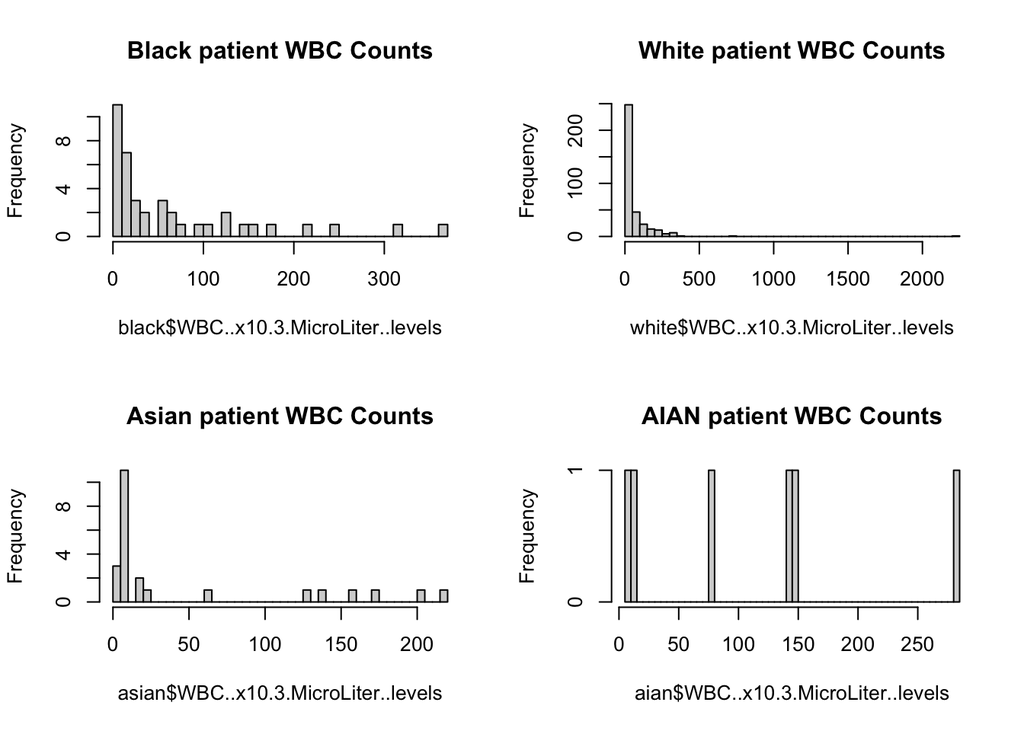

```r
# hist(black$WBC..x10.3.MicroLiter..levels, breaks = 50, main = "Black patient WBC Counts", xlim = c(0, 400))
# hist(white$WBC..x10.3.MicroLiter..levels, breaks = 50, main = "White patient WBC Counts", xlim = c(0, 400))
# hist(asian$WBC..x10.3.MicroLiter..levels, breaks = 50, main = "Asian patient WBC Counts", xlim = c(0, 400))
# hist(aian$WBC..x10.3.MicroLiter..levels, breaks = 50, main = "AIAN patient WBC Counts", xlim = c(0, 400))


hist(black$WBC..x10.3.MicroLiter..levels, breaks = 50, main = "Black patient WBC Counts")
hist(white$WBC..x10.3.MicroLiter..levels, breaks = 50, main = "White patient WBC Counts")
hist(asian$WBC..x10.3.MicroLiter..levels, breaks = 50, main = "Asian patient WBC Counts")
hist(aian$WBC..x10.3.MicroLiter..levels, breaks = 50, main = "AIAN patient WBC Counts")
```

```r
print("Black patients")
```

```
## [1] "Black patients"
```

```r
summary(black$WBC..x10.3.MicroLiter..levels)
```

```
##    Min. 1st Qu.  Median    Mean 3rd Qu.    Max.
##   1.100   7.425  28.800  68.430  93.975 364.000
```

```r
print(" ")
```

```
## [1] " "
```

```r
print("White patients ")
```

```
## [1] "White patients "
```

```r
summary(white$WBC..x10.3.MicroLiter..levels)
```

```
##    Min. 1st Qu.  Median    Mean 3rd Qu.    Max.
##    0.80    7.25   19.70   61.39   64.70 2208.00
```

Proceeding with caution on the t-test because the samples are not normally distributed for these categories

Will use a welch test because the two populations (Black vs White) have very unequal sample sizes

```r
t.test(black$WBC..x10.3.MicroLiter..levels, white$WBC..x10.3.MicroLiter..levels, paired = F)
```

```
##
##  Welch Two Sample t-test
##
## data:  black$WBC..x10.3.MicroLiter..levels and white$WBC..x10.3.MicroLiter..levels
## t = 0.44057, df = 62.789, p-value = 0.661
## alternative hypothesis: true difference in means is not equal to 0
## 95 percent confidence interval:
##  -24.89366  38.97321
## sample estimates:
## mean of x mean of y
##  68.43000  61.39022
```

```r
t.test(black$WBC..x10.3.MicroLiter..levels, white$WBC..x10.3.MicroLiter..levels, paired = F)
```

```
##
##  Welch Two Sample t-test
##
## data:  black$WBC..x10.3.MicroLiter..levels and white$WBC..x10.3.MicroLiter..levels
## t = 0.44057, df = 62.789, p-value = 0.661
## alternative hypothesis: true difference in means is not equal to 0
## 95 percent confidence interval:
##  -24.89366  38.97321
## sample estimates:
## mean of x mean of y
##  68.43000  61.39022
```